# Vapor pressure (LogVP) prediction

Author: Gaokeng Xiao

Date:2019-02-22

Data Set: https://pubs.acs.org.ccindex.cn/doi/10.1021/acs.jcim.6b00625 (accessed Nov 12, 2018).

## 1. 加载各个模块

```python
#Pandas and Numpy
import pandas as pd
import numpy as np

#RDkit for fingerprinting and cheminformatics
from rdkit import Chem, DataStructs
from rdkit.Chem import AllChem, rdMolDescriptors,Descriptors
from rdkit.Chem.EState import Fingerprinter

#Keras for deep learning
from keras.models import Sequential
from keras.layers import Dense, Dropout, Activation
from keras.callbacks import ReduceLROnPlateau,ModelCheckpoint
from keras.regularizers import l2 as l2_reg
from keras.optimizers import SGD

from sklearn.preprocessing import StandardScaler


#Matplotlib for plotting
from matplotlib import pyplot as plt
```

设置保存模型与归一化参数文件的路径

```python
import os
save_dir = "/public/gkxiao/work/VP"
```

## 2. 自定义函数以计算描述符

```python
#Define a helper function to append the Molweight to the E-state indices
def fps_plus_mw(mol):
    return np.append(Fingerprinter.FingerprintMol(mol)[0],round(Descriptors.MolWt(mol),4))
```

## 3.读入原始数据

### 3.1 从硬盘读入数据

```python
#Read the data
train = pd.read_csv("/public/gkxiao/work/VP/train.csv",sep=',')
test = pd.read_csv("/public/gkxiao/work/VP/test.csv",sep=',')
```

### 3.2 预览数据

```python
train.head()
```

|  | CAS RN | SMILES | LogVP |
| --- | --- | --- | --- |
| 0 | SRC003-80-1 | COC(F)(F)C(F)(F)C(F)(F)F | 2.75 |
| 1 | SRC003-80-0 | COC(F)(F)C(F)(F)F | 3.21 |
| 2 | 182346-21-0 | Brc1cc(Br)c(cc1)Oc1ccc(Br)c(Br)c1Br | -8.14 |
| 3 | 162853-25-0 | Clc1c(Oc2ccccc2)c(Cl)ccc1Cl | -3.55 |
| 4 | 162853-24-9 | Clc1cc(Oc2ccccc2)c(Cl)c(Cl)c1 | -3.66 |

```python
train.shape
```

```
(2034, 3)
```

```python
test.shape
```

```
(679, 3)
```

## 4. 描述符的计算与预处理

### 4.1 计算描述符

首先要将分子结构从SMILES格式转化为RDKit格式；然后用之间自定义的描述符计算函数计算描述符。

```python
#Add some new columns
train['Mol'] = train['SMILES'].apply(Chem.MolFromSmiles)
test['Mol'] = test['SMILES'].apply(Chem.MolFromSmiles)
```

```python
train['Descriptors'] = train['Mol'].apply(fps_plus_mw)
test['Descriptors'] = test['Mol'].apply(fps_plus_mw)
```

预览数据，发现新增了两列：Mol与Descriptors，其中Descriptors列要喂给Keras用来建立QSAR预测模型。

```python
train.head()
```

|  | CAS RN | SMILES | LogVP | Mol | Descriptors |
| --- | --- | --- | --- | --- | --- |
| 0 | SRC003-80-1 | COC(F)(F)C(F)(F)C(F)(F)F | 2.75 | <rdkit.Chem.rdchem.Mol object at 0x7f90b862bda0> | [0.0, 0.0, 0.0, 0.0, 0.0, 0.0, 1.0, 0.0, 0.0, ... |
| 1 | SRC003-80-0 | COC(F)(F)C(F)(F)F | 3.21 | <rdkit.Chem.rdchem.Mol object at 0x7f90b862be40> | [0.0, 0.0, 0.0, 0.0, 0.0, 0.0, 1.0, 0.0, 0.0, ... |
| 2 | 182346-21-0 | Brc1cc(Br)c(cc1)Oc1ccc(Br)c(Br)c1Br | -8.14 | <rdkit.Chem.rdchem.Mol object at 0x7f90b862be90> | [0.0, 0.0, 0.0, 0.0, 0.0, 0.0, 0.0, 0.0, 0.0, ... |
| 3 | 162853-25-0 | Clc1c(Oc2ccccc2)c(Cl)ccc1Cl | -3.55 | <rdkit.Chem.rdchem.Mol object at 0x7f90b862bee0> | [0.0, 0.0, 0.0, 0.0, 0.0, 0.0, 0.0, 0.0, 0.0, ... |
| 4 | 162853-24-9 | Clc1cc(Oc2ccccc2)c(Cl)c(Cl)c1 | -3.66 | <rdkit.Chem.rdchem.Mol object at 0x7f90b862bf30> | [0.0, 0.0, 0.0, 0.0, 0.0, 0.0, 0.0, 0.0, 0.0, ... |

Keras或tensorflow需要使用Numpy的数组作为输入，因此需要将数据转为Numpy数组格式。

最后得到四个数据，用于训练与测试模型。

```python
#Convert to Numpy arrays
X_train = np.array(list(train['Descriptors']))
y_train = train['LogVP'].values
X_test = np.array(list(test['Descriptors']))
y_test = test['LogVP'].values
```

### 4.2 描述符的预处理：将变量进行标准化

The preprocessing module further provides a utility class StandardScaler that implements the Transformer API to compute the mean and standard deviation on a training set so as to be able to later reapply the same transformation on the testing set.

```python
from sklearn import preprocessing
scaler = preprocessing.StandardScaler().fit(X_train)
```

```python
scaler
```

```
StandardScaler(copy=True, with_mean=True, with_std=True)
```

查看每一列的均值

```python
scaler.mean_
```

```
array([0.00000000e+00, 0.00000000e+00, 0.00000000e+00, 0.00000000e+00,
       4.91642085e-04, 0.00000000e+00, 1.46411013e+00, 6.88298918e-02,
       2.12143559e+00, 9.34119961e-03, 1.76007866e-01, 2.24532940e+00,
       3.61848574e-01, 9.34119961e-03, 4.57227139e-02, 4.39528024e-01,
       1.38298918e+00, 1.67649951e-01, 2.21730580e-01, 0.00000000e+00,
       5.99803343e-02, 0.00000000e+00, 0.00000000e+00, 1.02261554e-01,
       8.35791544e-03, 3.19567355e-02, 0.00000000e+00, 4.57227139e-02,
       1.40609636e-01, 8.45624385e-02, 6.39134710e-02, 3.49065880e-02,
       4.91642085e-04, 2.03539823e-01, 5.08849558e-01, 5.10324484e-01,
       1.47492625e-02, 2.94493609e-01, 0.00000000e+00, 0.00000000e+00,
       4.91642085e-04, 4.08062930e-02, 0.00000000e+00, 0.00000000e+00,
       4.91642085e-04, 4.67059980e-02, 0.00000000e+00, 1.27826942e-02,
       2.65486726e-02, 6.29301868e-02, 1.42576205e-02, 2.45821042e-03,
       1.67158309e-02, 5.90953786e-01, 0.00000000e+00, 0.00000000e+00,
       0.00000000e+00, 0.00000000e+00, 0.00000000e+00, 0.00000000e+00,
       2.45821042e-03, 4.91642085e-04, 0.00000000e+00, 0.00000000e+00,
       0.00000000e+00, 4.91642085e-04, 0.00000000e+00, 0.00000000e+00,
       0.00000000e+00, 8.70206490e-02, 0.00000000e+00, 0.00000000e+00,
       0.00000000e+00, 0.00000000e+00, 1.17994100e-02, 0.00000000e+00,
       0.00000000e+00, 0.00000000e+00, 0.00000000e+00, 1.88412599e+02])
```

```python
scaler.scale_
```

```
array([1.00000000e+00, 1.00000000e+00, 1.00000000e+00, 1.00000000e+00,
       2.21675522e-02, 1.00000000e+00, 1.67341995e+00, 2.84267776e-01,
       3.46686843e+00, 1.01179177e-01, 5.63119727e-01, 3.09363706e+00,
       7.39289119e-01, 1.14835005e-01, 2.49628817e-01, 7.86770513e-01,
       1.99269208e+00, 8.13429369e-01, 6.95186254e-01, 1.00000000e+00,
       2.82810031e-01, 1.00000000e+00, 1.00000000e+00, 3.71508390e-01,
       9.62878230e-02, 2.06724243e-01, 1.00000000e+00, 2.63054245e-01,
       5.17056967e-01, 3.32931366e-01, 3.25642281e-01, 2.01422708e-01,
       2.21675522e-02, 4.96662664e-01, 7.61131974e-01, 9.43404155e-01,
       1.20547591e-01, 1.34592110e+00, 1.00000000e+00, 1.00000000e+00,
       2.21675522e-02, 4.50943007e-01, 1.00000000e+00, 1.00000000e+00,
       2.21675522e-02, 2.24553452e-01, 1.00000000e+00, 1.12335644e-01,
       1.75386035e-01, 2.87347870e-01, 1.26573730e-01, 4.95193662e-02,
       1.42721927e-01, 1.33290435e+00, 1.00000000e+00, 1.00000000e+00,
       1.00000000e+00, 1.00000000e+00, 1.00000000e+00, 1.00000000e+00,
       4.95193662e-02, 2.21675522e-02, 1.00000000e+00, 1.00000000e+00,
       1.00000000e+00, 2.21675522e-02, 1.00000000e+00, 1.00000000e+00,
       1.00000000e+00, 5.11229525e-01, 1.00000000e+00, 1.00000000e+00,
       1.00000000e+00, 1.00000000e+00, 1.12443177e-01, 1.00000000e+00,
       1.00000000e+00, 1.00000000e+00, 1.00000000e+00, 1.01252400e+02])
```

保存scale的归一化参数到硬盘以便一下次重新使用

```python
scaler_data_ = np.array([scaler.mean_, scaler.scale_])
np.save("/public/gkxiao/work/VP/vp_scaler.npy", scaler_data_)
```

数据归一化预处理

```python
X_train = scaler.transform(X_train)
X_test = scaler.transform(X_test)
```

## 5. 深度学习

### 5.1 建立网络

```python
model = Sequential()
#model.add(Dense(output_dim=10, input_dim=X_train.shape[1]))
model.add(Dense(input_dim=X_train.shape[1],units=50))
model.add(Activation("sigmoid"))

#model.add(Dense(output_dim=1))
model.add(Dense(units=1))
model.add(Activation("linear"))
```

### 5.2 训练模型

```python
model_name = 'vp_trained_model.h5'
model.compile(loss='mean_squared_error', optimizer=SGD(lr=0.001, momentum=0.9, nesterov=True),metrics=['accuracy'])
filepath="model_{epoch:02d}-{val_acc:.2f}.hdf5"
checkpoint = ModelCheckpoint(os.path.join(save_dir, filepath), monitor='val_acc',verbose=1, save_best_only=True,period=5,mode='max')
history = model.fit(X_train, y_train,
                    batch_size=3000,
                    epochs=25000,
                    validation_data=(X_test, y_test),
                    shuffle=True,
                    callbacks=[checkpoint]
                   )
```

```
Train on 2034 samples, validate on 679 samples

Epoch 00005: val_acc improved from -inf to 0.00295, saving model to /public/gkxiao/work/VP/model_05-0.00.hdf5

Epoch 00010: val_acc did not improve from 0.00295

Epoch 00015: val_acc did not improve from 0.00295

Epoch 00020: val_acc did not improve from 0.00295

Epoch 00025: val_acc did not improve from 0.00295

Epoch 00030: val_acc did not improve from 0.00295

Epoch 00035: val_acc did not improve from 0.00295

Epoch 00040: val_acc did not improve from 0.00295

Epoch 00045: val_acc did not improve from 0.00295

Epoch 00050: val_acc did not improve from 0.00295

Epoch 00055: val_acc did not improve from 0.00295

Epoch 00060: val_acc did not improve from 0.00295

Epoch 00065: val_acc improved from 0.00295 to 0.00442, saving model to /public/gkxiao/work/VP/model_65-0.00.hdf5

Epoch 00070: val_acc did not improve from 0.00442

Epoch 00075: val_acc improved from 0.00442 to 0.00589, saving model to /public/gkxiao/work/VP/model_75-0.01.hdf5

Epoch 00080: val_acc did not improve from 0.00589

Epoch 00085: val_acc did not improve from 0.00589

Epoch 00090: val_acc did not improve from 0.00589

Epoch 00095: val_acc did not improve from 0.00589

```

[output cut: 9946 more lines]

```
Epoch 24965: val_acc did not improve from 0.00884

Epoch 24970: val_acc did not improve from 0.00884

Epoch 24975: val_acc did not improve from 0.00884

Epoch 24980: val_acc did not improve from 0.00884

Epoch 24985: val_acc did not improve from 0.00884

Epoch 24990: val_acc did not improve from 0.00884

Epoch 24995: val_acc did not improve from 0.00884

Epoch 25000: val_acc did not improve from 0.00884
```

```python
y_pred = model.predict(X_test)
rms = (np.mean((y_test.reshape(-1,1) - y_pred)**2))**0.5
#s = np.std(y_test -y_pred)
print("Neural Network RMS of test set:", rms)
```

```
Neural Network RMS of test set: 0.9674143503076905
```

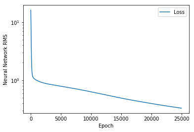

```python
plt.plot(history.history["loss"], label="Loss")
plt.xlabel('Epoch')
plt.ylabel('Neural Network RMS')
plt.yscale("log")
plt.legend()
```

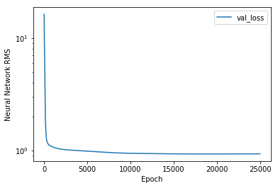

```python
plt.plot(history.history["val_loss"], label="val_loss")
plt.xlabel('Epoch')
plt.ylabel('Neural Network RMS')
plt.yscale("log")
plt.legend()
```

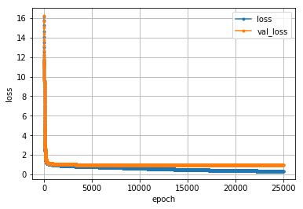

```python
import matplotlib.pyplot as plt
loss = history.history['loss']
val_loss = history.history['val_loss']
epochs = len(loss)
plt.plot(range(epochs), loss, marker = '.', label = 'loss')
plt.plot(range(epochs), val_loss, marker = '.', label = 'val_loss')
plt.legend(loc = 'best')
plt.grid()
plt.xlabel('epoch')
plt.ylabel('loss')
plt.show()
```

```python
import pickle
file=open("/public/gkxiao/work/VP/vp_model_history.pkl","wb")
pickle.dump(history.history, file)
file.close
```

```
<function BufferedWriter.close>
```

### 5.3 保存模型

```python
#save model
model.save('/public/gkxiao/work/VP/vp_model.h5')
model.save_weights('/public/gkxiao/work/VP/vp_model_weights.h5')
```

### 5.4 模型质量评估

绘制训练集与测试集的预测值与观察值散点图。如果之前已经训练、保存过模型，去掉下面的注释，直接读入模型再进行模型的评估。

```python
#load model
from keras.models import load_model
model = load_model("/public/gkxiao/work/VP/vp_model.h5")
model.load_weights('/public/gkxiao/work/VP/vp_model_weights.h5')
```

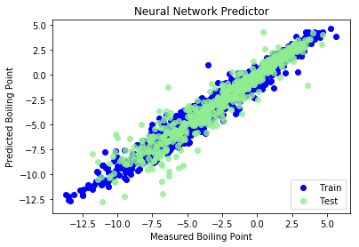

```python
import matplotlib.pyplot as plt
plt.scatter(y_train,model.predict(X_train), label = 'Train', c='blue')
plt.title('Neural Network Predictor')
plt.xlabel('Measured Boiling Point')
plt.ylabel('Predicted Boiling Point')
plt.scatter(y_test,model.predict(X_test),c='lightgreen', label='Test', alpha = 0.8)
plt.legend(loc=4)
plt.show()
```

模型质量评估

```python
from sklearn.metrics import mean_squared_error,r2_score,mean_absolute_error
y_pred=model.predict(X_train)
train_mse=mean_squared_error(y_train,y_pred)
train_mae=mean_absolute_error(y_train,y_pred)
train_r2 = r2_score(y_train,y_pred)
test_pred=model.predict(X_test)
test_mse=mean_squared_error(y_test,test_pred)
test_mae=mean_absolute_error(y_test,test_pred)
test_r2 = r2_score(y_test,test_pred)
print("Train set: MSE=",round(train_mse,2),"MAE=",round(train_mae,2),"R^2=",round(train_r2,2))
print("Test set: MSE=",round(test_mse,2),"MAE=",round(test_mae,2),"R^2=",round(test_r2,2))
```

```
Train set: MSE= 0.33 MAE= 0.39 R^2= 0.97
Test set: MSE= 0.94 MAE= 0.61 R^2= 0.93
```

从平均绝对误差(MAE)来看，模型质量相当好。

## 6. 预测新化合物的蒸汽压

### 6.1 建立预测集

待预测化合物用SMILES编码，保存在一个预测集里(predset)，并计算描述符

```python
#Structure (SMILES code)  of new compound
smi = 'F/C(=C(/F)C(F)(F)F)C(F)(F)F'
#create a prediction set and calculate descriptor
predset=pd.DataFrame({'SMILES':[smi]})
predset['Mol'] = predset['SMILES'].apply(Chem.MolFromSmiles)
predset['Descriptors'] = predset['Mol'].apply(fps_plus_mw)
```

### 6.2 从硬盘加载原先保存的模型

```python
#load model
from keras.models import load_model
model = load_model("/public/gkxiao/work/VP/vp_model.h5")
#model.load_weights('/public/gkxiao/work/rdkit_deeplearn/bp_keras_model_weights.h5')
```

### 6.3 读入数据预处理（归一化）参数

```python
scaler_data_ = np.load("/public/gkxiao/work/VP/vp_scaler.npy")
Xmean_, Xscale_ = scaler_data_[0], scaler_data_[1]
```

### 6.4 对预测集化合物的描述符进行归一化处理

```python
Xscaled = np.array(list(predset['Descriptors']))
Xscaled = (Xscaled - Xmean_)/Xscale_
```

### 6.5 预测蒸汽压

```python
#predict boiling point
predset['LogVP'] = model.predict(Xscaled)[0][0]
```

```python
#show the predset
predset
```

|  | SMILES | Mol | Descriptors | LogVP |
| --- | --- | --- | --- | --- |
| 0 | F/C(=C(/F)C(F)(F)F)C(F)(F)F | <rdkit.Chem.rdchem.Mol object at 0x7f907438ec10> | [0.0, 0.0, 0.0, 0.0, 0.0, 0.0, 0.0, 0.0, 0.0, ... | 2.802145 |

```python
#print result
print("Vapor Pressure :", round(model.predict(Xscaled)[0][0],2))
```

```
Vapor Pressure : 2.8
```

### 6.6 绘制2D结构

```python
from rdkit.Chem import Draw
mol = Chem.MolFromSmiles(smi)
AllChem.Compute2DCoords(mol)
Draw.MolToFile(mol,"noimage.png")
```

[figure not shown]